# gaming_academic_performance_eda

## Impact of Gaming Habits on Academic Performance

## The objective of this project is to analyze how gaming habits, lifestyle patterns, stress levels, and study behavior affect students' academic performance using exploratory data analysis techniques in Python.

## Import Libraries

```python
import pandas as pd
import numpy as np
import seaborn as sns
import matplotlib.pyplot as plt
```

## Load Dataset

```python
data = pd.read_csv(r"C:\Gaming Dataset\Gaming_Academic_Performance.csv")
```

```python
data.head(10)
```

|  | student_id | age | gender | gaming_hours | study_hours | sleep_hours | attendance | gaming_genre | social_activity | device_usage | reaction_time_ms | addiction_score | stress_level | grades | performance_level | addiction_risk | sleep_quality |
| --- | --- | --- | --- | --- | --- | --- | --- | --- | --- | --- | --- | --- | --- | --- | --- | --- | --- |
| 0 | 1 | 22 | Male | 7.23 | 8.78 | 6.96 | 91.44 | FPS | 3.25 | 9.36 | 235.84 | 15 | Low | 86 | High | Medium | Poor Sleep |
| 1 | 2 | 19 | Male | 0.07 | 8.72 | 7.63 | 63.63 | Casual | 1.02 | 3.21 | 328.71 | 2 | Medium | 98 | High | Low | Healthy Sleep |
| 2 | 3 | 23 | Female | 1.73 | 9.56 | 4.40 | 83.26 | Casual | 3.46 | 5.56 | 313.61 | 5 | High | 91 | High | Low | Poor Sleep |
| 3 | 4 | 20 | Female | 6.62 | 1.68 | 7.83 | 75.04 | RPG | 1.46 | 11.78 | 241.84 | 15 | Low | 33 | Low | Medium | Healthy Sleep |
| 4 | 5 | 22 | Female | 5.36 | 5.83 | 5.55 | 65.57 | FPS | 1.01 | 8.23 | 249.31 | 12 | Low | 59 | Medium | Medium | Poor Sleep |
| 5 | 6 | 18 | Male | 7.16 | 6.84 | 8.03 | 68.11 | RPG | 3.74 | 10.90 | 242.75 | 19 | Low | 58 | Medium | Medium | Healthy Sleep |
| 6 | 7 | 22 | Female | 0.46 | 7.40 | 6.55 | 91.25 | Casual | 1.81 | 2.86 | 320.20 | 2 | Medium | 94 | High | Low | Poor Sleep |
| 7 | 8 | 23 | Female | 4.78 | 6.79 | 5.37 | 66.46 | FPS | 2.85 | 9.96 | 271.21 | 12 | Medium | 62 | Medium | Medium | Poor Sleep |
| 8 | 9 | 20 | Female | 4.55 | 7.93 | 8.76 | 72.50 | FPS | 1.00 | 9.48 | 272.39 | 11 | Medium | 81 | High | Medium | Healthy Sleep |
| 9 | 10 | 19 | Male | 0.29 | 4.24 | 7.83 | 71.39 | Casual | 3.07 | 5.39 | 318.59 | 5 | Medium | 82 | High | Low | Healthy Sleep |

## Basic Exploration

```python
data.info()
```

[output not shown]

```python
data.describe()
```

|  | student_id | age | gaming_hours | study_hours | sleep_hours | attendance | social_activity | device_usage | reaction_time_ms | addiction_score | grades |
| --- | --- | --- | --- | --- | --- | --- | --- | --- | --- | --- | --- |
| count | 8000.00000 | 8000.000000 | 8000.000000 | 8000.000000 | 8000.000000 | 8000.000000 | 8000.000000 | 8000.000000 | 8000.000000 | 8000.000000 | 8000.000000 |
| mean | 4000.50000 | 19.983625 | 4.085773 | 5.460581 | 6.493453 | 79.886525 | 2.507790 | 7.586315 | 271.105839 | 9.923875 | 66.081500 |
| std | 2309.54541 | 2.587072 | 2.308801 | 2.575787 | 1.442656 | 11.580419 | 1.441128 | 2.710035 | 29.440675 | 5.014975 | 22.254331 |
| min | 1.00000 | 16.000000 | 0.000000 | 1.000000 | 4.000000 | 60.000000 | 0.000000 | 1.100000 | 183.260000 | 0.000000 | 0.000000 |
| 25% | 2000.75000 | 18.000000 | 2.130000 | 3.240000 | 5.240000 | 69.780000 | 1.287500 | 5.560000 | 247.160000 | 6.000000 | 50.000000 |
| 50% | 4000.50000 | 20.000000 | 4.130000 | 5.460000 | 6.505000 | 79.695000 | 2.500000 | 7.610000 | 270.475000 | 10.000000 | 67.000000 |
| 75% | 6000.25000 | 22.000000 | 6.060000 | 7.660000 | 7.730000 | 90.100000 | 3.760000 | 9.600000 | 294.690000 | 14.000000 | 84.000000 |
| max | 8000.00000 | 24.000000 | 8.000000 | 10.000000 | 9.000000 | 100.000000 | 5.000000 | 13.950000 | 347.870000 | 23.000000 | 100.000000 |

```python
data.shape
```

```
(8000, 17)
```

```python
data.isnull().sum()
```

```
student_id           0
age                  0
gender               0
gaming_hours         0
study_hours          0
sleep_hours          0
attendance           0
gaming_genre         0
social_activity      0
device_usage         0
reaction_time_ms     0
addiction_score      0
stress_level         0
grades               0
performance_level    0
addiction_risk       0
sleep_quality        0
dtype: int64
```

```python
data.duplicated().sum()
```

```
np.int64(0)
```

## Feature Engineering

```python
data["grades"] = np.where(data["grades"] > 100, 100, data["grades"]).round().astype(int)
```

```python
data["addiction_score"] = np.where(data["addiction_score"] < 0, 0, data["addiction_score"]).round().astype(int)
```

## Create Performance Category

```python
# Creating performance categories based on grades

data["performance_level"] = pd.cut(
    data["grades"],
    bins=[-1,50,75,100],
    labels=["Low","Medium","High"]
)
```

## Gaming Addiction Risk

```python
# Creating addiction_risk categories based on addiction_score

data["addiction_risk"] = pd.cut(
    data["addiction_score"],
    bins=[-1,10,20,30],
    labels=["Low","Medium","High"]
)
```

## Sleep Quality

```python
# Creating sleep_quality categories based on sleep_hours

data["sleep_quality"] = np.where(
    data["sleep_hours"] < 7,
    "Poor Sleep",
    "Healthy Sleep"
)
```

## Grades Distribution

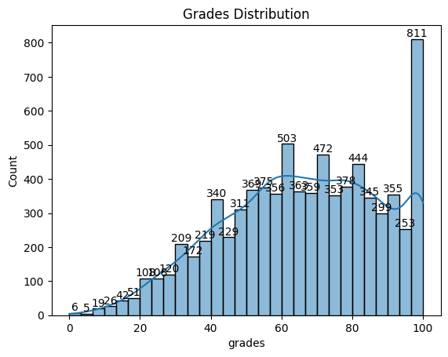

```python
ax = sns.histplot(data["grades"], kde=True)
ax.bar_label(ax.containers[0])
plt.title("Grades Distribution")
plt.show()
```

## Gaming Hours

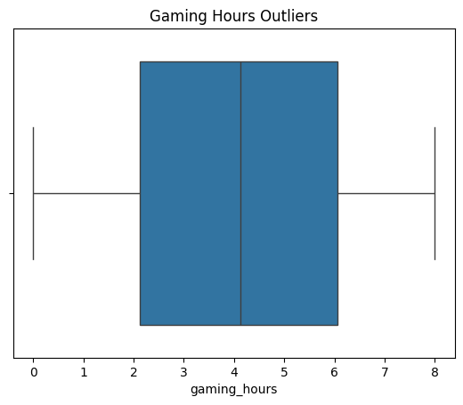

```python
sns.boxplot(x=data["gaming_hours"])
plt.title("Gaming Hours Outliers")
plt.show()
```

## Stress Levels

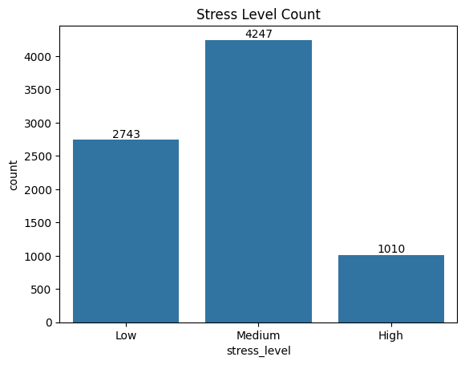

```python
ax = sns.countplot(x=data["stress_level"])
ax.bar_label(ax.containers[0])
plt.title("Stress Level Count")
plt.show()
```

## Stress Level vs Grades

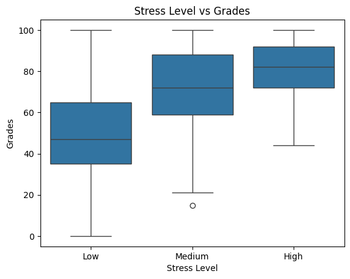

```python
sns.boxplot(
    x="stress_level",
    y="grades",
    data=data
)

plt.title("Stress Level vs Grades")
plt.xlabel("Stress Level")
plt.ylabel("Grades")

plt.show()
```

## Gaming Hours vs Grades

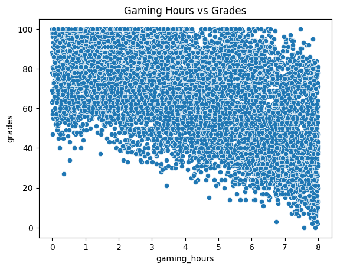

```python
sns.scatterplot(
    x="gaming_hours",
    y="grades",
    data=data
)

plt.title("Gaming Hours vs Grades")
plt.show()
```

## Study Hours vs Grades

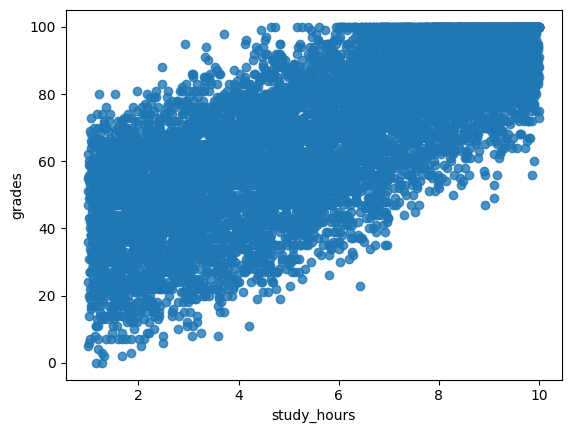

```python
sns.regplot(
    x="study_hours",
    y="grades",
    data=data
)
```

## Sleep vs Stress

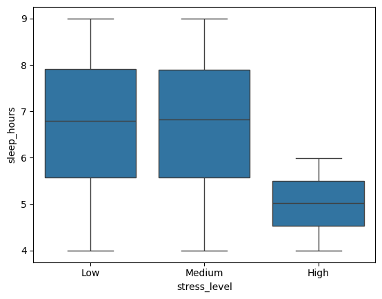

```python
sns.boxplot(
    x="stress_level",
    y="sleep_hours",
    data=data
)
```

## Addiction Score vs Grades

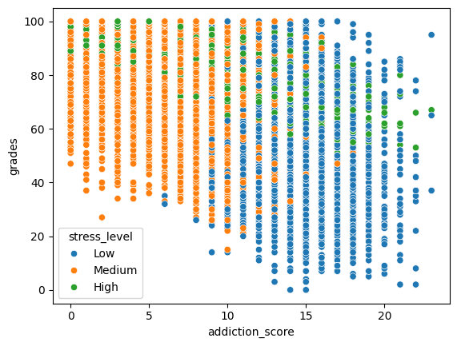

```python
sns.scatterplot(
    x="addiction_score",
    y="grades",
    hue="stress_level",
    data=data
)
```

## Correlation Heatmap

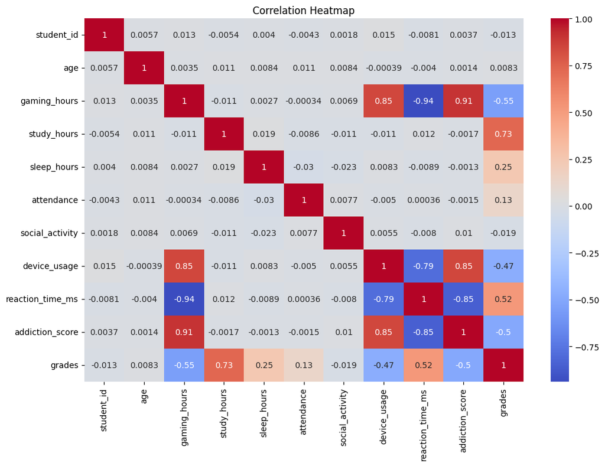

```python
plt.figure(figsize=(12,8))

sns.heatmap(
    data.corr(numeric_only=True),
    annot=True,
    cmap="coolwarm"
)

plt.title("Correlation Heatmap")
plt.show()
```

## Average Grades by Gaming Genre

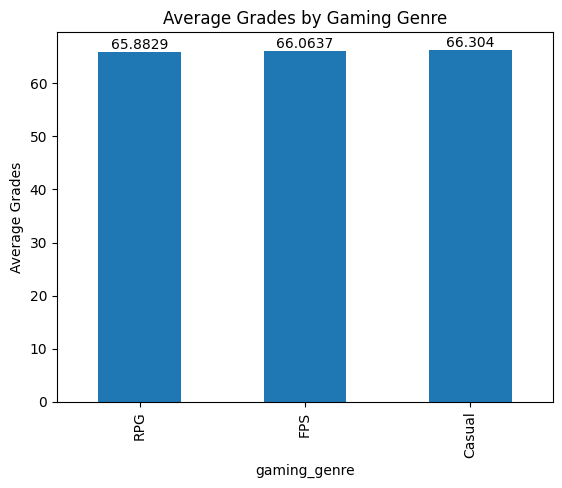

```python
genre_perf = data.groupby("gaming_genre")["grades"].mean().sort_values()

ax = genre_perf.plot(kind="bar")
ax.bar_label(ax.containers[0])
plt.title("Average Grades by Gaming Genre")
plt.ylabel("Average Grades")
plt.show()
```

## Average Grades by Addiction Risk

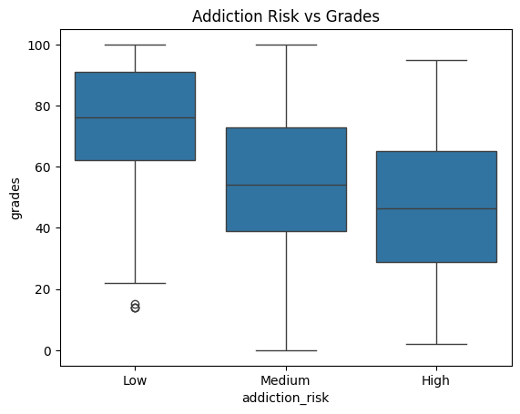

```python
sns.boxplot(
    x="addiction_risk",
    y="grades",
    data=data
)

plt.title("Addiction Risk vs Grades")
plt.show()
```

## Gender-Based Analysis

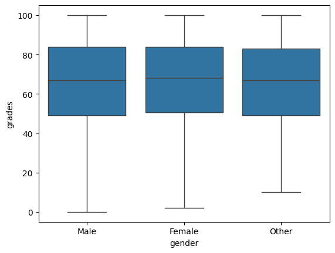

```python
sns.boxplot(
    x="gender",
    y="grades",
    data=data
)
```

## Attendance vs Performance

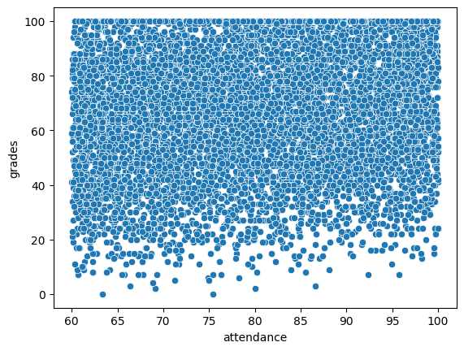

```python
sns.scatterplot(
    x="attendance",
    y="grades",
    data=data
)
```

## Outlier Detection

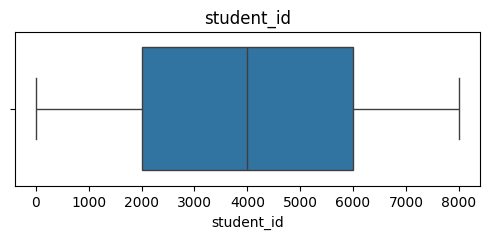

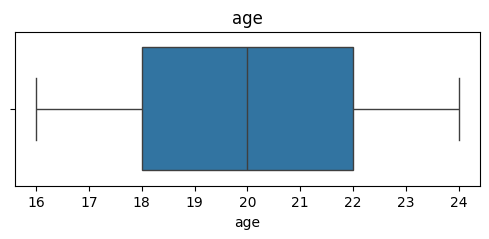

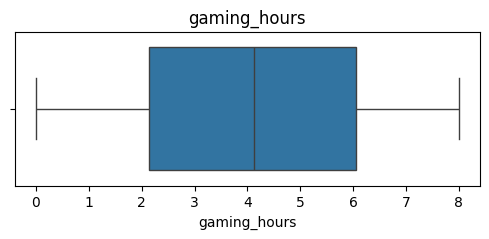

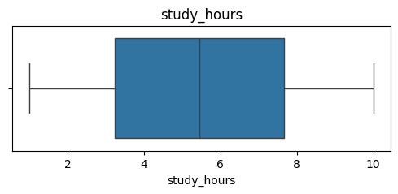

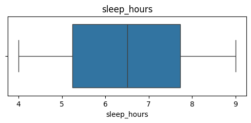

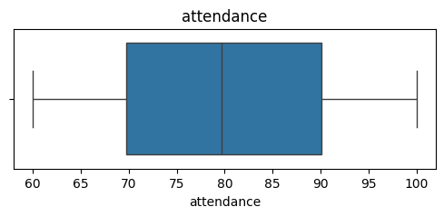

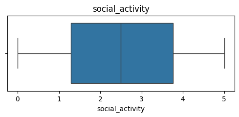

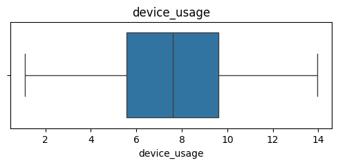

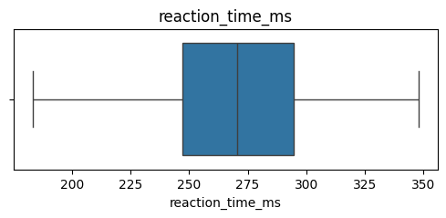

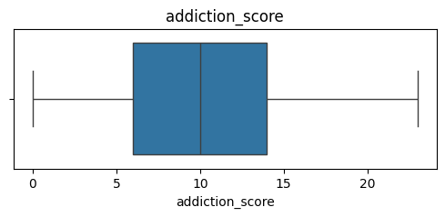

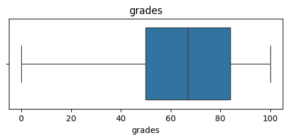

```python
numeric_cols = data.select_dtypes(include=np.number).columns

for col in numeric_cols:
    plt.figure(figsize=(6,2))
    sns.boxplot(x=data[col])
    plt.title(col)
    plt.show()
```

## Key Insights

• Students with high gaming hours tend to score lower grades.

• Study hours positively impact academic performance.

• Students with healthy sleep patterns generally perform better academically.

• Excessive device usage may contribute to reduced study efficiency.

## Conclusion

This analysis explored the relationship between gaming behavior, lifestyle habits, and academic performance among students.

This project demonstrates the use of Python for data cleaning, exploratory data analysis, visualization, and behavioral insight generation.

## Recommendations

• Encourage balanced gaming habits among students.

• Promote healthy sleep schedules and stress management.

• Monitor students with high addiction risk scores.

• Increase awareness regarding excessive screen time.

• Provide academic support to low-attendance students.

# Future Scope

- Build a machine learning model to predict student grades.
- Develop an interactive Power BI dashboard.
- Perform clustering analysis for student segmentation.
- Apply statistical testing for deeper behavioral analysis.